# Chapter 4 モーメント分配法

## A11.8 最終モーメントのチェック

静定条件を満足するためには、節点におけるすべての部材のモーメントの代数和がゼロに等しくなければならない。この要件だけでは、さまざまな分配モーメントや到達モーメントにおいて誤りが発生している可能性があるため、最終モーメントが正しいことの証明にはならない。連続条件は、任意の節点における弾性曲線の最終的な傾きが、その節点に集まるすべての部材に共通であることを示している。したがって、完全なチェックを行うためには、最終モーメントが各部材の等しい傾きと一致していることを証明する必要がある。節点の本来想定された固定またはロック状態からの回転は、完全に分配モーメントおよび到達モーメントによるものである。したがって、実際の回転は、分配モーメントと到達モーメントの代数和に等しい端部モーメントを受けた単純支持梁の端部の回転に等しくなる。これらの端部モーメントは、最終モーメントから元の固定端モーメントを引いたものに等しく、 $\Delta M$ モーメントと呼ばれる。

A7章より、単純支持梁上の任意の点における傾きは、荷重としての $M/EI$ 図によるせん断力に等しい。

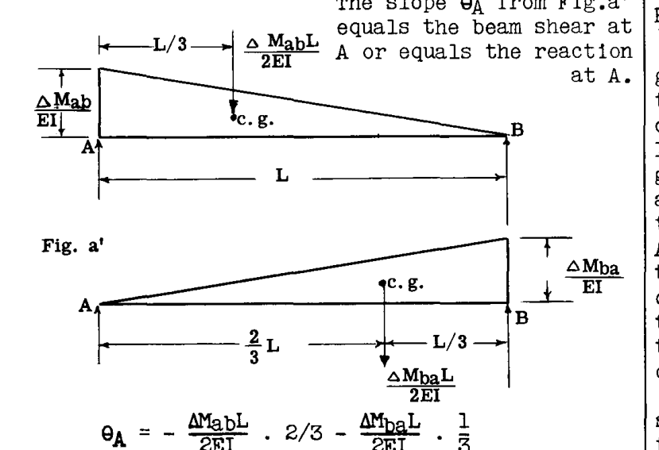

Fig. a’

Fig. a’ より、傾き $\theta_A$ は A における梁のせん断力に等しく、または A における反力に等しい。

$$= \frac{(\Delta M_{ab} + .5 \Delta M_{ba})}{3EK_{ab}}$$

ここで

$$K_{ab} = \frac{I}{L} \quad \text{of } AB$$

A に集まる部材に対して傾き $\theta_A$ は同一でなければならないため、AB および AC のような任意の2つの部材のモーメント増分間の一般的な関係は、次のようでなければならない。

$$\frac{\Delta M_{ab} + .5 \Delta M_{ba}}{\Delta M_{ac} + .5 \Delta M_{ca}} = \frac{K_{ab}}{K_{ac}}$$

この式を、到達モーメントがバランス分配モーメントと同じ符号を持つという仮定された符号規約と一致させるために、上記の式は次のように修正されなければならない。-

$$\frac{\Delta M_{ab} - .5 \Delta M_{ba}}{\Delta M_{ac} - .5 \Delta M_{ca}} = \frac{K_{ab}}{K_{ac}} \quad \text{---(5)}$$

式(5)が満足されれば、モーメント分配の精度が確立される。

## A11.9 部材が一直線上にない連続骨組の端部モーメント。節点回転のみ*

航空機構造において連続トラス骨組は非常によく見られる。溶接鋼管トラス胴体は、溶接によって節点で連続性を維持する部材で構成されている。着陸装置はしばしば、接続点で連続した2つの部材を持つ。このような構造の部材は通常、高い軸方向応力を伝達し、これが節点の移動を引き起こし、節点が剛であるため部材の曲げを引き起こす。これらのモーメントは部材の横方向のたわみを生じさせ、部材の軸荷重に横方向たわみを乗じた値による追加の二次モーメントをもたらす。これらの影響については、後続の節で扱う。本節では、モーメント分配法にさらに慣れるため、節点移動および二次モーメントの影響は無視する。

### 例題 6

Fig. A11.19 は、簡略化された着陸装置のシャーシ問題を示している。車軸上の垂直荷重による2つの部材の曲げモーメントを求めることが求められている。この問題は、端部 A および B における3つの異なる拘束度を用いて解かれている。節点 O は溶接継手であり、この節点を通じて完全な連続性が仮定されている。Fig. A11.20 に示す解は、一次曲げモーメント下での節点回転によるモーメントのみを示している。軸変形および部材たわみによる二次モーメントの影響は、これらの解では省略されている。これらの要因については、後続の節で扱う。

実際の設計問題では、A 点および B 点における拘束度は、使用されるフィッティングのタイプや、隣接する胴体または翼構造の剛性によって決定される。後の例で示されるように、モーメント分配法は、隣接する構造の剛性を難なく考慮することを可能にするが、最小仕事などの方法では、多くの未知数を得るために解かなければならない方程式の数が非常に多くなるため、実用的ではない。

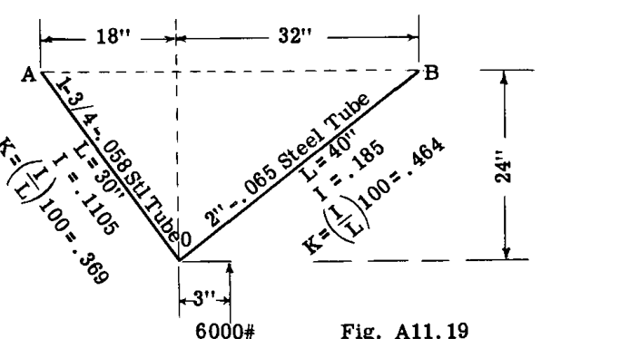

Fig. All.19

### 条件 I の解、両端 A および B で固定

Fig. A11.20 を参照すると、すべての節点は回転に対してロックされている、あるいは固定されていると仮定される。6000# の垂直車軸荷重は、節点 O のまわりに $3 \times 6000 = 18000 \text{ in. lb.}$ の反時計回りのモーメントを生じる。符号は正である（Art. A11.2 参照）。節点 O を解放またはロック解除すると、アンバランスモーメントは 18000 であり、節点 O の静的平衡のために -18000 が必要である。節点 O は、メンバー OB に $-18000(.464 / (.464 + .369)) = -10030$ を分配し、残りの $-18000(.369 / (.464 + .369)) = -7970$ を OA に分配することによってバランスされる。O におけるこれらの分配バランスモーメントは、A および B に到達モーメントを生じる。

したがって、B への到達モーメントは $.5 \times -10030 = -5015$ 、A への到達モーメントは $.5 \times -7970 = -3985$ となる。固定節点である節点 A に進むと、-3985 のアンバランスモーメントは剛な支持部によって完全にバランスされ、節点が仮想的な固定状態から解放されても回転は生じない。節点 B でも同様の動作が行われる。最終的な端部モーメントは図に示す通りである。

### 条件 II の解、端部 A および B がピン支持

この条件では、端部 A および B は自由支持である。これらの確実に自由であることがわかっている節点をロックおよびロック解除する代わりに、それらは真の状態のままにされる。したがって、端部 O からの到達モーメントはゼロになる。A と B は両方ともピン支持であるため、部材 OA と OB の相対剛度比は条件 I と同じままであり、したがって条件 I で使用されたものと同じ K または剛度因子を節点 O におけるモーメント分配に使用できる。節点 O は条件 I と同様にバランスされるが、A および B への到達モーメントはゼロである。

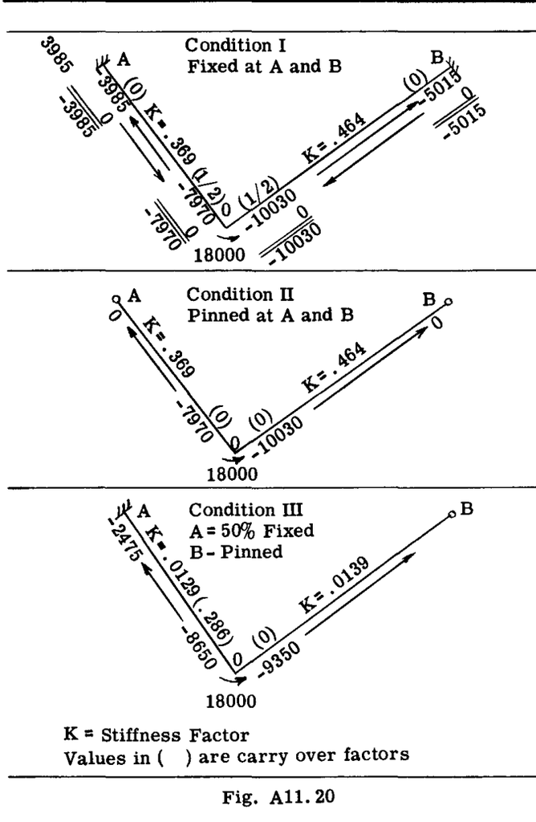

Fig. All.20

### 条件 III の解。A は 50% 固定、B はピン支持。

各部材の上端における固定度が異なるため、剛度および到達因子を詳細に検討する。条件 I では、両部材の上端が固定されていたため、各部材の相対剛度は部材の $I/L$ に比例し、この比が使用された。剛度の一般的な表現は $K = \frac{EI(3+F)}{L}$ であり、到達因子は $\frac{2F}{3+F}$ である。部材 OA について、A は 50% 固定であるため $F = .5$ であり、部材 OB について、B は自由支持であるため $F = 0$ である。したがって、部材 OA について、

$$K = \frac{EI}{L}(3 + .5) = \frac{3.5 EI}{L} = \frac{3.5 \times .1105 E}{30} = .0129 E$$

$$\text{O から A への C.O. 因子} = \frac{2 \times .5}{3 + .5} = .286$$

部材 OB について、

$$K = \frac{EI}{L}(3 + 0) = \frac{3 \times .185 \times E}{40} = .0139 E$$

$$\text{O から B への C.O. 因子} = \frac{2 \times 0}{3 + 0} = 0$$

Fig. A11.20 の節点 O を考慮すると、18000 in.lb. の外力モーメントは、それらの剛度因子に比例して2つの部材に -18000 を分配することによってバランスされる。したがって、 $-18000(.0129 / (.0129 + .0139)) = -8650 \text{ in lbs.}$ が OA によって抵抗され、残りの $-18000(.0139 / (.0129 + .0139)) = -9350$ が OB に分配される。O から A への到達モーメントは $.286 \times -8650 = -2475$ であり、O から B へはゼロである（Fig. A11.20 参照）。

## Example Problem #7

Fig. A11.21 は、3つの部材で構成される構造を示している。部材 AO は、その中間点で 120# の横荷重を受ける。節点 A は固定、B は自由支持、C は 25% 固定であり、節点 O はすべての部材間で連続性を維持している。部材 AO 上の横荷重による3つの部材の端部モーメントを決定する。

### 解法 #1

Fig. A11.21 は、修正されていない基本状態の「クロス」法を用いた解を示している。すべての3つの部材が両端固定であると仮定することから開始する。したがって、各部材の相対剛度 K は各部材の $I/L$ に比例する。これらの K 値は Fig. A11.21 にリストされている。

各節点における各部材の分配率 D は $K / \sum K$ に等しく、各節点の各部材の $\Box$ 内に記録される。したがって、任意のアンバランスモーメントは、これらの分配率に従って節点部材間に分配される。すべての部材の到達因子は 1/2 である。外力荷重による固定端モーメントが3つの部材に対して計算される。部材 AO について、固定端モーメントは $PL/8 = 120 \times 20 / 8 = 300 \text{ in. lb.}$ である。他の2つの部材は横荷重がないため、固定端モーメントはゼロである。

この解法における節点考慮の順序は AOBC の繰り返しである。節点 A から始めて節点を解放するが、部材 AO は実際には固定支持によって保持されているため、回転は発生せず、300 のバランスモーメントは支持部によって完全に提供され、部材 AO によるものはゼロである。O への到達モーメント $C_1$ はゼロである。節点 O を解放すると、300 のアンバランスモーメントは、それらの D 値に従って3つの部材間で -300 を分配することによってバランスされる。したがって、 $-300 \times .416 = -125$ が OA へ、 $-300 \times .168 = -50$ が OC へ、 $-125$ が OB へ分配される。混乱を防ぐために、すべての分配バランスモーメントの下に線を引くことが推奨される。したがって、これらの線より上の値はこれ以上考慮する必要はなく、後の節点のバランスにおいて線より下の値のみを考慮すればよい。節点 O におけるモーメントを分配した直後に、適切な到達モーメントを各部材の他端に送る。したがって、-62.5 を A へ、-62.5 を B へ、-25 を C へ送る。次に節点 B を考慮する。アンバランスモーメントは -62.5 であり、ピン支持は剛性を持たない、すなわち回転に対する抵抗がないため、62.5 を BO に分配することでバランスされる。62.5 の下に線を引き、31.25 の到達モーメントを O に置く。次に節点 C を考慮する。-25 のアンバランスモーメントは、 $.75 \times 25 = 18.75$ を CO に分配し、残りの 6.25 を支持部に分配することでバランスされる。支持部の固定度は 25% と仮定されているためである。18.75 の下に線を引いて、9.37 の到達モーメントを O に送る。これで1サイクルが完了した。節点 A に戻ると、線の下に -62.5 がある。これは、OA にゼロ、固定支持に 62.5 を分配することによってバランスされる。AO へのゼロ分配モーメントの下に線を引き、到達モーメントゼロを O に置く。節点 O を2回目に考慮すると、アンバランスモーメントは $9.37 + 31.25 + 0 = 40.62$ 、すなわち縦欄の水平線より下のすべての値の合計である。この節点は、-17 を OA と OB に、-6.62 を OC に分配することによってバランスされる。Fig. A11.21 に示すように、これらのバランスモーメントの下に線を引き、到達モーメントを他端に送ってから、節点 B に進む。

この一般的なプロセスは、節点 A が 5次バランスされ、他の節点がそれぞれ 4次バランスされるまで繰り返される。図に示すように、分配値は非常に小さくなり、高い精度が得られたことが明らかである。各節点における最終的な端部モーメントは、各列の値の代数和に等しい。最終モーメントの上には、区別するための記号として二重線が引かれている。図において、文字 b と c はバランスモーメントと到達モーメントを指し、添え字はバランスまたは到達操作の部材を指している。同じ結果に達するために、任意の節点考慮順序を使用できる。

### 解法 #2

Fig. A11.22 は第2の解を示している。A、B、Cにおける端部条件が既知であるため、部材の修正剛度因子を修正到達因子とともに求めることができ、これにより節点 O を1回だけバランスさせ、この最終的な遠端モーメントを到達させるだけで済む。

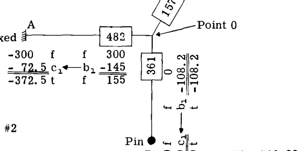

Fig. All.22

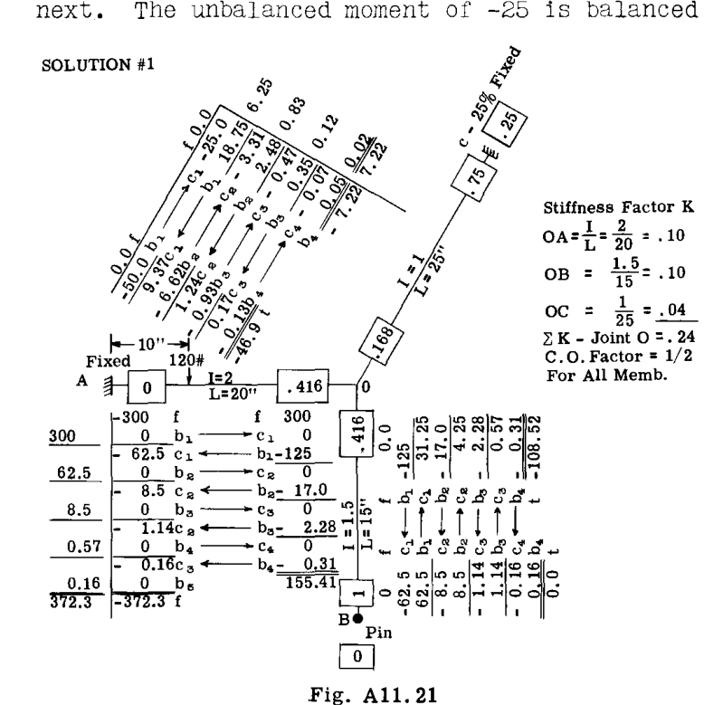

Fig. All.21

各部材のモーメント。図は、各部材の修正または実際の剛度と到達因子の計算を示している。これらが既知であれば、部材 AO 上の横荷重による固定端モーメントを計算することから、以前と同様に解が開始される。節点 B と C は解放され、固定端モーメントが存在しないため、バランスは不要であり、節点はロック解除ではなく、解法 #1 のように実際の拘束状態のままにされる。仮想的な固定状態から節点 O を解放すると、アンバランスモーメントは 300 であり、これは節点 O における新しい分配率に従って3つの接続部材間で -300 を分配することによってバランスされる。したがって、 $-300 \times .482 = -145$ が OA へ、 $-300 \times .361 = -108.2$ が OB へ、 $-300 \times .157 = -47$ が OC へ分配される。A への到達モーメントは $-145 \times .5 = -72.5$ 、B への到達モーメントは $-108.2 \times 0 = 0$ 、C への到達モーメントは $-47 \times .154 = -7.2$ となる。

## Example Problem #8

Figure A11.23 は胴体サイドトラスの前部を示している。エンジンマウントおよび着陸装置部材の偏心により、外力モーメントが図のように節点 A、B、D に生じる。さらに、機器の設置による横方向の荷重が部材 BE および CD に作用している。胴体の溶接継手が節点を通じて部材の剛な連続性を生み出すと仮定すると、問題は偏心節点モーメントと2つの横方向荷重によるすべての部材の端部モーメントを求めることである。たわみおよび軸荷重による節点移動および二次モーメントの影響は、この例では無視する。

### 解法

Table A11.2 は、各トラス部材の剛度因子の計算を示している。I および H の後方の胴体トラスは、これらの節点に 50% の固定度を与えると仮定されている。Table A11.2 では、他端における 50% の固定度を使用して、部材 GI、FI、および FH の修正剛度因子が計算されている。Table A11.2 の最後の列は、各節点で交差する部材の部材剛度因子の総和を示している。

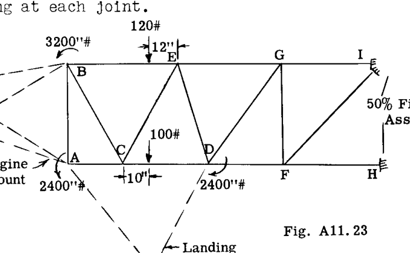

Fig. All.23

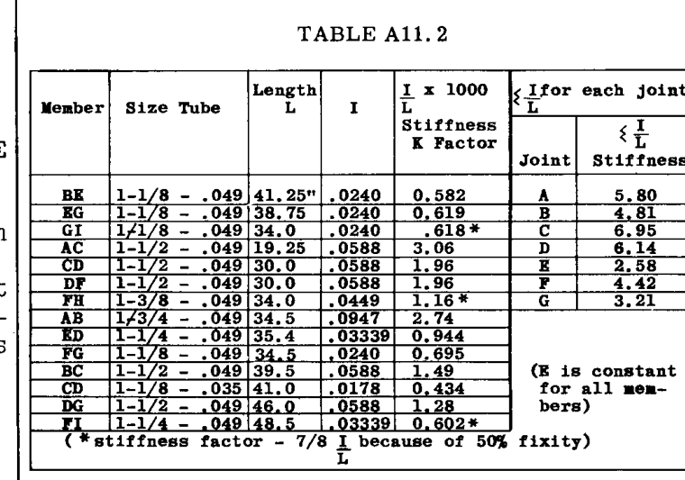

TABLE All.2

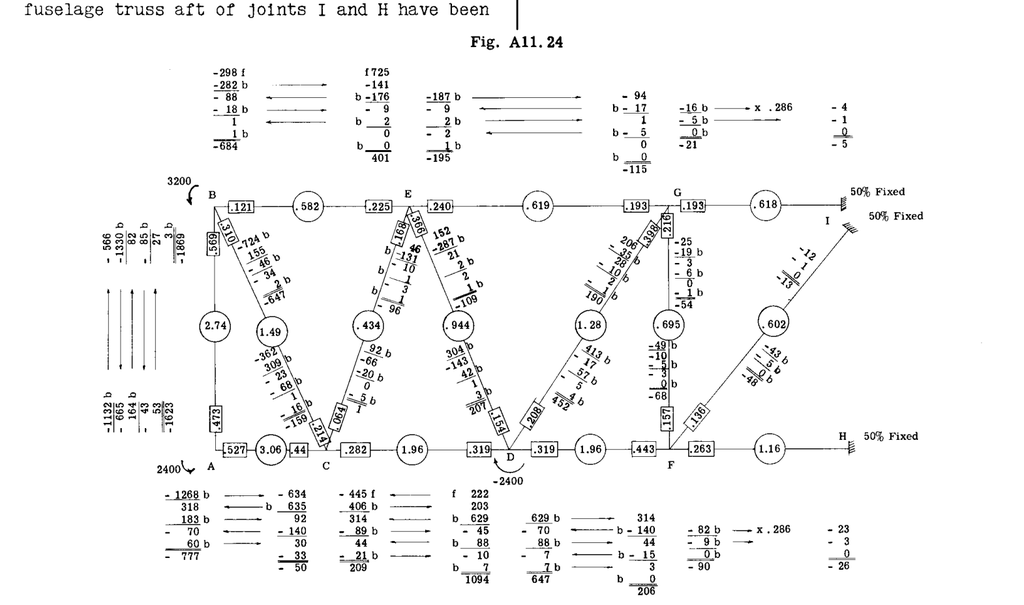

Fig. All.24

Fig. A11.24 は問題の解を示している。この解の手順は以下の通りであった。

Table A11.2 で計算された各部材の剛度 K は、各トラス部材に隣接する円内に記録されている。すべての部材の到達因子は 1/2 であるが、修正された部材 GI、FI、および FH については、50% 固定端への到達因子は .286 である。各節点における各部材の分配率は、各部材の端部に記録されており、 $K / \sum K$ に等しい。

解法の次のステップは、部材上の横荷重による固定端モーメントを計算することである。

部材 BE について

$$M_{BE} = \frac{Pab^2}{L^2} = \frac{120 \times 29.25 \times 12^2}{41.25^2} = -298 \text{ in. lb.}$$

$$M_{EB} = \frac{120 \times 29.25^2 \times 12}{41.25^2} = 725 \text{ in. lb.}$$

$$M_{CD} = \frac{100 \times 20^2 \times 10}{30^2} = -445$$

$$M_{DC} = \frac{100 \times 10^2 \times 20}{30^2} = 222$$

#### 節点 A について考慮する:-

アンバランスモーメント = 2400。次のように -2400 を分配することでバランスする:-

AC へ $-2400 \times .527 = -1268$ 。C への到達モーメント = -634。

AB へ $-2400 \times .473 = -1132$ 。B への到達モーメント = -566。

#### 節点 B へ進む:-

アンバランスモーメント = $(-566 + 3200 - 298) = 2336$ 。節点は、接続部材に次のように -2336 を分配することによってバランスされる:-

BA へ $-2336 \times .569 = -1330$ 。A への到達モーメント = -665。

BC へ $-2336 \times .310 = -724$ 。C への到達モーメント = -362。

BE へ $-2336 \times .121 = -282$ 。E への到達モーメント = -141。

すべての分配モーメントの下に線を引く便利な方法は、後の節点のバランスにおける混乱を防ぐために使用される。

#### 節点 C へ進む:-

アンバランスモーメント = $(-634 - 362 - 445) = -1441$ 。節点は、次のように 1441 を分配することによってバランスされる:-

CA へ $1441 \times .44 = 635$ 。A への到達モーメント = 318。

CB へ $1441 \times .214 = 309$ 。B への到達モーメント = 155。

CE へ $1441 \times .064 = 92$ 。E への到達モーメント = 46。

CD へ $1441 \times .282 = 406$ 。D への到達モーメント = 203。

このプロセスは、残りのトラス節点に対しても継続される。すべての節点が1回バランスされた後、節点 A に戻ると、線の下に $(318 - 665) = -347$ のアンバランスモーメントがある。節点を2回目バランスする。183 を AC に、164 を AB に分配し、これらの半分の到達モーメントをそれぞれ端部 C と B に送る。

これで学生は、Fig. A11.24 に示す解の残りの部分をチェックできるはずである。

この解は、任意の節点考慮順序で行うことができる。特定の節点がほぼバランスされているように見える場合は、当面はそれをスキップし、かなりアンバランスな節点を考慮するのが最善である。

各部材の端部における最終モーメントは、二重線の下に示されている。

## Example Problem #9

Fig. A11.25 は、溶接鋼管胴体の断面を示している。上部および下部トラスのウェブ部材である上部および下部部材は、図に示すように機器設置による横方向荷重を受ける。節点を通過する完全な連続性を仮定して、これらの横方向荷重による矩形フレームの端部曲げモーメントを決定することが求められている。

### 解法

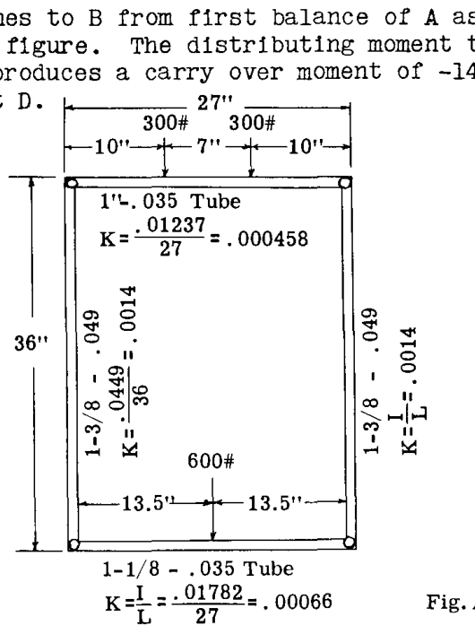

Fig. All.25

Fig. A11.26 は解を示している。部材剛度因子に基づく分配率は、各部材の端部の $\Box$ 内に示されている。最初のステップは、Table A11.1 の式を使用して、部材 AB および CD 上の横荷重による固定端モーメントを計算することである。大きさは、AB に対して 1890“#、CD に対して 2025”# である。

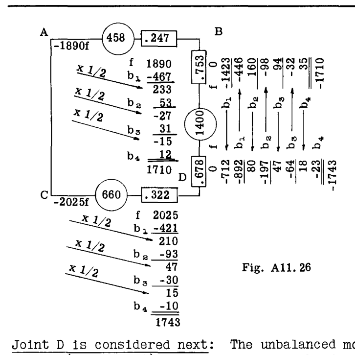

Fig. All.26

節点 D が次に考慮される。 $(2025 - 712) = 1313$ のアンバランスモーメントは、接続部材に -1313 を分配することによってバランスされる。

部材 DB へは $-1313 \times .678 = -892$ 、残りの -421 は DC へ分配される。B への到達モーメントは -446 である。C から D への到達は、部材 AB について前述したように、対称性により、バランスモーメント B = -421 の半分で符号が逆の 210 になる。

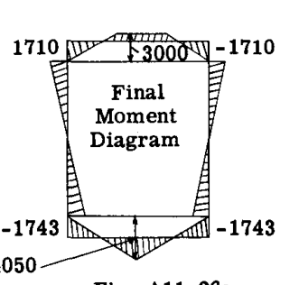

Fig. All.26a

## A11.10 断面が変化する部材を持つ連続構造物*

Art. A11.3、4および5では、均一な断面の梁に対する固定端モーメント、剛性、および到達因子の式の導出が考慮された。部材が変化する断面を持つ日常の設計において、多くのケースが発生する。本節では、変化する慣性モーメントを持つ梁の固定端モーメント、剛性、および到達因子の計算を説明する。これらの因子に対する軸荷重の影響はここでは考慮せず、後の節で扱う。

### (A) 与えられた梁荷重に対する固定端モーメントの計算

Fig. A11.27 は、変化する慣性モーメントを持ち、100# の単一集中荷重を支持する固定端梁を示している。この荷重に対する梁モーメント図は3つの部分に分けて考慮される。Fig. A11.28 は、梁が A と B で単純支持され、100# の荷重を支持していると仮定した静的モーメント曲線を示している。Fig. A11.29 は、他の2つの部分、すなわち、両端に固定を生じさせる未知のモーメント $M_A$ および $M_B$ による三角形のモーメント図を示している。この図では、単一値の代わりに、 $M_A$ と $M_B$ は任意に 100 とされている。

Fig. A11.30 は、Fig. A11.29 の3つのモーメント図に対する $M/I$ 図を示している。梁は10個の等しい帯に分割され、 $M/I$ 曲線は、各帯または部分の端部におけるモーメント値を Fig. A11.27 の対応する I 値で割ることによって得られる。

梁端部における固定条件から、梁の弾性曲線の傾きは両端でゼロであることがわかる。同様に、一方の端部の接線から他方の端部へのたわみはゼロである。これらの事実をモーメント面積法の原理で表すと、次式が得られる。

$$\int_{0}^{L} \frac{M}{I} dx = 0 \quad \text{---(5)} \quad (M/I \text{ 図の面積の和がゼロに等しい})$$

$$\int_{0}^{L} \frac{Mx}{I} dx = 0 \quad \text{---(6)} \quad (M/I \text{ 図のモーメント荷重のいずれかの端部のまわりのモーメントがゼロに等しい})$$

(注: E は通常一定とみなされるため、上記の式では分母から省略されている。)

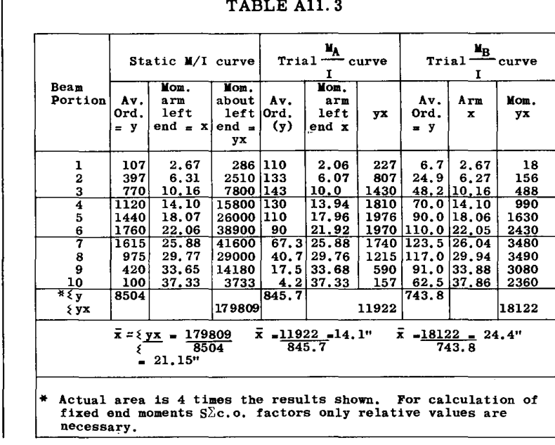

TABLE All.3

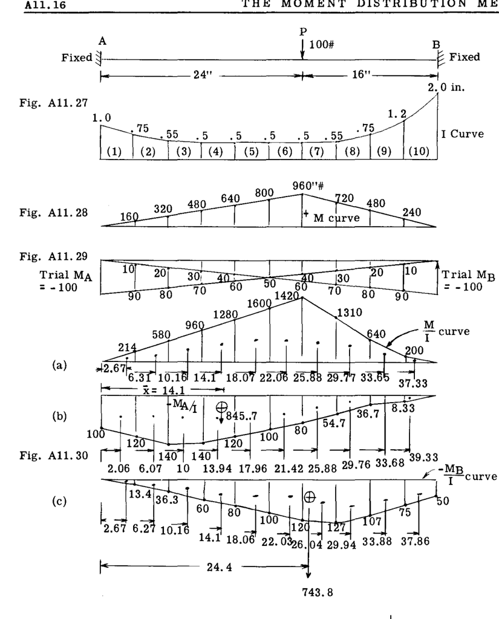

Fig. All.30

Table A11.3 は、Fig. A11.30 の3つの $M/I$ 図の面積と図心を計算するための計算を示している。表の値を式(5)および(6)に代入する。

$$\frac{845.7}{100} M_A + \frac{743.8}{100} M_B + 8504 = 0 \quad \text{---(7)}$$

$$\frac{11922}{100} M_A + \frac{18122}{100} M_B + 179809 = 0 \quad \text{---(8)}$$

分母の 100 という値は、 $M_A$ および $M_B$ に対して 100 という試行値が仮定されたためである。式(7)および(8)を解くと、次式が得られる。

$$M_A = -315 \text{ in. lb.} \quad \text{and} \quad M_B = -785 \text{ in. lb.}$$

### (B) 到達因子の計算

$$845.7 \times 14.1 + \frac{743.8}{100} M_B \times 24.4 = 0$$

または

$$M_B = -66 \text{ in. lb.}$$

$M_A$ は 100 と仮定されたため、A から B への到達因子は次のようになる。

$$\frac{-66}{100} = -.66$$

B から A への到達因子を求めるには、B のまわりのモーメントをとり、ゼロに等しく置く。

したがって、

$$743.8 \times 15.6 + \frac{845.7}{100} M_A \times 25.9 = 0$$

これから

$$M_A = -53.2 \text{ in. lb.}$$

したがって、B から A への到達因子は次のようになる。

$$\frac{-53.2}{100} = -.532$$

(注: 本書で使用されているモーメント符号規約では、到達因子はプラスとなる。)

### (C) 梁剛度因子の計算

梁の一方の端部 A が自由支持され、他端 B が固定されている場合、A 端における剛度因子は、A において弾性曲線の単位回転を生じさせるために必要なモーメントによって測定される。

Art. A11.4 において、均一断面の梁に対して $E\theta_A = M_A L / 4I$ または $M_A = 4E I \theta_A / L$ であることが証明された。連続構造において、任意の節点で、すべての部材は同じ $\theta$ を持つため、 $4E\theta$ は一定であり、任意の角柱梁の剛度 K は $I/L$ に比例する。変断面の梁の場合、剛度因子 K は次のように書くことができる。-

$$K = c I_0 / L \quad \text{---(9)}$$

ここで、 $I_0$ は特定の基準断面における慣性モーメントであり、c は各非均一部材に対して求められる定数である。したがって、非均一部材に対して、

$$E\theta_A = M_A L / 4 c I_0 \quad \text{---(10)}$$

面積モーメント傾斜原理により、B が固定されているときの A における傾きは、A と B の間の $M/I$ 図の面積に等しい。

$M_A = 100$ とすると、 $M_B$ は $-66 \text{ in. lb.}$ に等しいことがわかった。したがって、

$$E\theta_A = 4(845.7 - .66 \times 743.8) = 1419$$

4 という値は帯の幅によるものであり、実際の面積が必要であり、Table A11.3 では平均縦座標のみが使用されたためである。

この結果を式(10)に等しく置くと、

$$1419 = \frac{100 \times 40}{4c \times 1} \quad \text{、これから } c = .707$$

$I_0$ は A 端における値、すなわち 1 とされた（Fig. A11.27 参照）。

したがって、

$$K_{AB} = .707 I_A / L$$

同様に B 端に対しては:-

$$E\theta_B = 4(743.8 - .532 \times 845.7) = \frac{100 \times 40}{4c \times 1}$$

これから

$$c = .85 \quad \text{and} \quad K_{BA} = .85 I_A / L$$

## A11.11 横移動による未知の節点変位を持つフレーム*

これまで扱った例題では、特定の構造の節点は移動せずに回転するか、または明確な量の移動を伴うと仮定されていた。しかし、節点の移動は、軸荷重による部材の収縮および伸長、および斜めせん断部材の欠如による横方向の揺れ（横移動）によって生じる可能性がある。軸応力による節点移動の影響に関する問題については、後の節で扱う。本節では、矩形フレームの横移動がフレーム曲げモーメントに及ぼす影響のみを考慮する。

Fig. A11.31 は、節点の回転のみが発生するフレームの例（軸変形は無視）を示しているが、Fig. A11.32 は、横移動が発生し、節点が回転だけでなく移動も受ける条件を示している。

横移動による曲げモーメントを決定する方法はいくつかある。ここでは1つの方法のみを提示し、それは例題の解法によって最もよく説明できる。

### 例題 1

Fig. A11.33 は、一方の脚に分布側方荷重を受けるシングルベイの矩形ベントを示している。各部材の K または $I/L$ 値は図に示されている。

与えられた荷重の下で、フレームが右に揺れる、換言すれば、節点 B と C がかなりの水平移動を受けることは明らかである。モーメント分配法は、節点回転のみが発生することを前提としている。この構造に対してこの仮定を真にするために、Fig. A11.34 に示すように、フレームの横移動を防ぐ仮想的な支持を節点 C に追加する。フレーム内の端部モーメントは、モーメント分配プロセスによって求められる。Fig. A11.34 はこのプロセスの結果を示している。説明すると、解法は、部材 AB の固定端モーメントの計算から始まる。

$$M_{AB} = W L^2 / 12 = (300 \times 25^2) / 12 = 15.63 \text{ k-ft}$$

この値は、適切な符号とともに、Fig. A11.34 に示すように部材 AB の数値欄の先頭に書き込まれる。

ここで節点 B を考慮すると、15.63 のアンバランス節点モーメントは次のように分配される:-

部材 BA へ: $-15.63(40 / 190) = -3.27$ 。節点 A への到達 = $-3.27 / 2 = -1.63$

部材 BC へ: $-15.63(150 / 190) = -12.36$ 。節点 C への到達 = $-12.36 / 2 = -6.18$

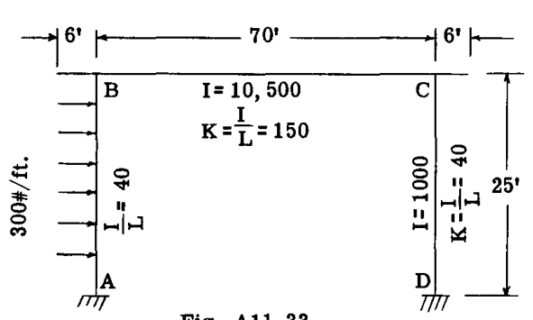

Fig. All.33

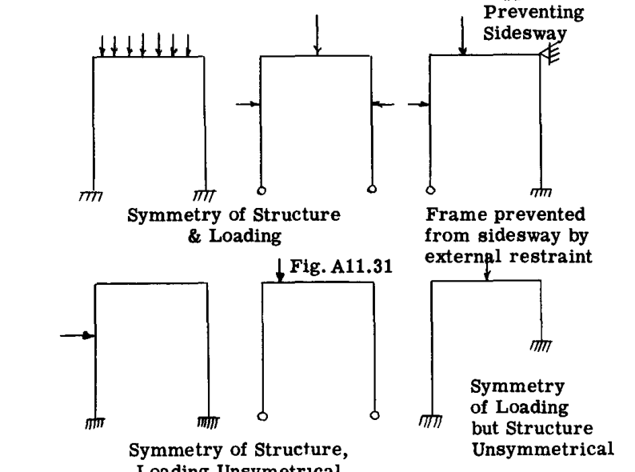

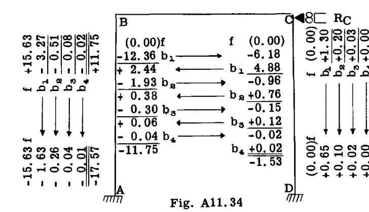

Fig. All.34